# ASSIGNMENT

This assignment will be described in multiple parts. You will need to write a report that answers the questions detailed below. Ultimately, you will need to complete the entire assignment in a single R markdown document that can be processed by knitr and be transformed into an HTML file. 1 Throughout your report make sure you always include the code that you used to generate the output you present. When writing code chunks in the R markdown document, always use echo = TRUE so that someone else will be able to read the code. This assignment will be evaluated via peer assessment so it is essential that your peer evaluators be able to review the code for your analysis.

### Loading an dprocessing data.

```r
    setwd("C:/Users/Vivek/Desktop/data Science/reproducible")
    if (!file.exists("activity.csv")){
        unzip("repdata_data_activity.zip")
    }

    activityData <- read.csv("activity.csv",header =TRUE)
```

## Total number of steps taken per day

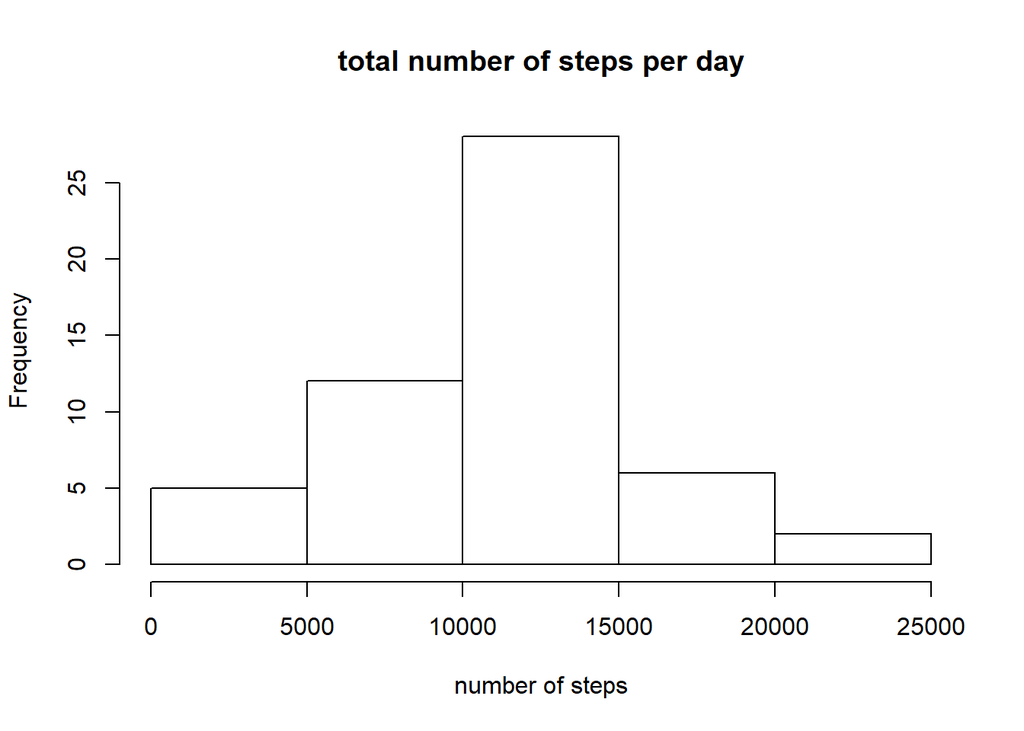

```r
    totalSteps <- aggregate(steps~date,activityData,FUN = sum)
    hist(totalSteps$steps,main = "total number of steps per day", xlab = "number of steps" )
```

```r
    meanSteps <- mean(totalSteps$steps,na.rm = TRUE)
```

### Median of total number of steps taken.

```r
    medianSteps <- median(totalSteps$steps,na.rm = TRUE)
```

Median of total no. of steps taken is 10765

## Average daily activity pattern

### Time Series Plot

[figure not shown]

```r
    meanStepsbyInterval <- aggregate(steps~interval,activityData,FUN = mean)
    plot(meanStepsbyInterval$interval, meanStepsbyInterval$steps,type = "l")
    title(main = "Average Daily Activity Pattern", xlab = "5-minutes Interval",ylab = "Average no. of steps")
```

### Maximum number of steps.

```r
    maxInt <-  meanStepsbyInterval[which.max(meanStepsbyInterval$steps),]
```

Maximum no. of steps taken are 206.1698113 in 835 interval

## Inputing missing value

### Total no. of missing values

```r
    totalmissings <- sum(is.na(activityData$steps))
```

There are total 2304 missing values in the activity dataset. These missing values has to be filled using some appropriate strategy. Here strategy used is to fill the missing value by the mean of number of steps taken in that particular interval.

### Strategy for filling in all missing values

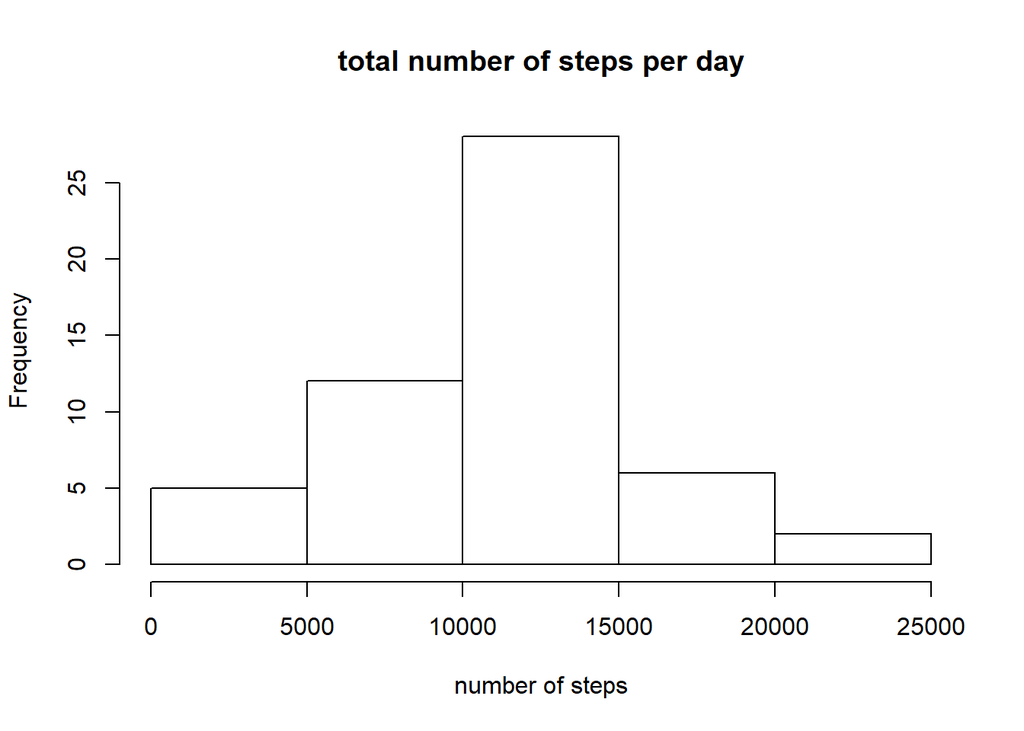

```r
    activityData_new <- transform(activityData, steps = ifelse(is.na(activityData$steps),
                                             meanStepsbyInterval$steps[match(meanStepsbyInterval$interval,activityData$interval)],
                                                               activityData$steps))
    totalSteps_new <- aggregate(steps~date,activityData,FUN = sum)
    hist(totalSteps_new$steps,main = "total number of steps per day", xlab = "number of steps" )
```

```r
    meanSteps_new <- mean(totalSteps_new$steps,na.rm = TRUE)
    medianSteps_new <- median(totalSteps_new$steps,na.rm = TRUE)

    diff_mean <- meanSteps_new - meanSteps
    diff_median <- medianSteps_new - medianSteps
    diff_total <- totalSteps_new - totalSteps
```

### Diffence in Activity pattern between weekdays and week-ends

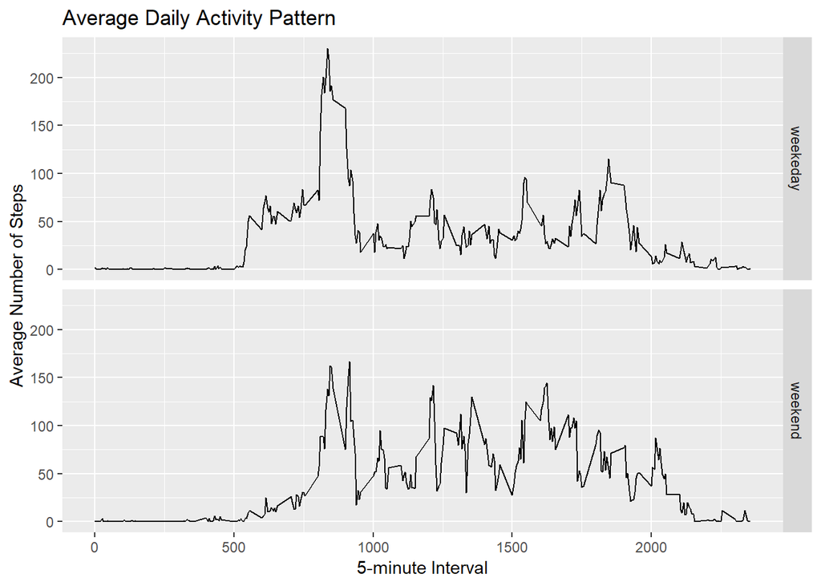

```r
     DayType <- function(date) {
         day <- weekdays(date)
         if (day %in% c('Monday', 'Tuesday', 'Wednesday', 'Thursday', 'Friday'))
              return ("weekeday")
         else if (day %in% c('Saturday', 'Sunday'))
              return ("weekend")
         else
              stop ("Invalid Date Format.")
    }
    activityData_new$date <- as.Date(activityData_new$date)
    activityData_new$day <- sapply(activityData_new$date, FUN = DayType)

    # Make a panel plot containnig a time-series plot of the 5-minute interval
    # and the average number of steps taken across all weekdays or weekends
    meanStepsByDay <- aggregate(steps ~ interval + day, activityData_new, mean)

    library(ggplot2)
    ggplot(data = meanStepsByDay, aes(x = interval, y = steps)) +
      geom_line() +
      facet_grid(day ~ .) +
      ggtitle("Average Daily Activity Pattern") +
      xlab("5-minute Interval") +
      ylab("Average Number of Steps")
```